# clientes4_davidmestres_v2

```python
from google.colab import drive
import pandas as pd
import numpy as np
import plotly.express as px


drive.mount('/content/drive')


ruta_recibos = '/content/drive/MyDrive/201904 sales reciepts.csv'
ruta_clientes = '/content/drive/MyDrive/customer.csv'

try:
    df_receipts = pd.read_csv(ruta_recibos)
    df_customer = pd.read_csv(ruta_clientes)
    print("Datos cargados correctamente desde Drive\n")

    #  Inspección inicial rápida
    print("--- PRIMERAS FILAS DE VENTAS ")
    display(df_receipts.head(3))
    print("\n PRIMERAS FILAS DE CLIENTES ")
    display(df_customer.head(3))

except FileNotFoundError:
    print("Error: No se encontraron los archivos.")
```

[output not shown]

|  | transaction_id | transaction_date | transaction_time | sales_outlet_id | staff_id | customer_id | instore_yn | order | line_item_id | product_id | quantity | line_item_amount | unit_price | promo_item_yn |
| --- | --- | --- | --- | --- | --- | --- | --- | --- | --- | --- | --- | --- | --- | --- |
| 0 | 7 | 2019-04-01 | 12:04:43 | 3 | 12 | 558 | N | 1 | 1 | 52 | 1 | 2.5 | 2.5 | N |
| 1 | 11 | 2019-04-01 | 15:54:39 | 3 | 17 | 781 | N | 1 | 1 | 27 | 2 | 7.0 | 3.5 | N |
| 2 | 19 | 2019-04-01 | 14:34:59 | 3 | 17 | 788 | Y | 1 | 1 | 46 | 2 | 5.0 | 2.5 | N |

```
 PRIMERAS FILAS DE CLIENTES
```

|  | customer_id | home_store | customer_first-name | customer_email | customer_since | loyalty_card_number | birthdate | gender | birth_year |
| --- | --- | --- | --- | --- | --- | --- | --- | --- | --- |
| 0 | 1 | 3 | Kelly Key | Venus@adipiscing.edu | 2017-01-04 | 908-424-2890 | 1950-05-29 | M | 1950 |
| 1 | 2 | 3 | Clark Schroeder | Nora@fames.gov | 2017-01-07 | 032-732-6308 | 1950-07-30 | M | 1950 |
| 2 | 3 | 3 | Elvis Cardenas | Brianna@tellus.edu | 2017-01-10 | 459-375-9187 | 1950-09-30 | M | 1950 |

```python
# 1- A: Info y estadísticas
print(" INFO Y ESTADÍSTICAS DE VENTAS ")
print(df_receipts.info())
display(df_receipts.describe(include='all'))

print("\n INFO Y ESTADÍSTICAS DE CLIENTES ")
print(df_customer.info())
display(df_customer.describe(include='all'))
```

```
 INFO Y ESTADÍSTICAS DE VENTAS
<class 'pandas.core.frame.DataFrame'>
RangeIndex: 49894 entries, 0 to 49893
Data columns (total 14 columns):
 #   Column            Non-Null Count  Dtype
---  ------            --------------  -----
 0   transaction_id    49894 non-null  int64
 1   transaction_date  49894 non-null  object
 2   transaction_time  49894 non-null  object
 3   sales_outlet_id   49894 non-null  int64
 4   staff_id          49894 non-null  int64
 5   customer_id       49894 non-null  int64
 6   instore_yn        49894 non-null  object
 7   order             49894 non-null  int64
 8   line_item_id      49894 non-null  int64
 9   product_id        49894 non-null  int64
 10  quantity          49894 non-null  int64
 11  line_item_amount  49894 non-null  float64
 12  unit_price        49894 non-null  float64
 13  promo_item_yn     49894 non-null  object
dtypes: float64(2), int64(8), object(4)
memory usage: 5.3+ MB
None
```

|  | transaction_id | transaction_date | transaction_time | sales_outlet_id | staff_id | customer_id | instore_yn | order | line_item_id | product_id | quantity | line_item_amount | unit_price | promo_item_yn |
| --- | --- | --- | --- | --- | --- | --- | --- | --- | --- | --- | --- | --- | --- | --- |
| count | 49894.000000 | 49894 | 49894 | 49894.000000 | 49894.000000 | 49894.000000 | 49894 | 49894.000000 | 49894.000000 | 49894.000000 | 49894.000000 | 49894.000000 | 49894.000000 | 49894 |
| unique | NaN | 29 | 26074 | NaN | NaN | NaN | 3 | NaN | NaN | NaN | NaN | NaN | NaN | 2 |
| top | NaN | 2019-04-19 | 10:11:25 | NaN | NaN | NaN | Y | NaN | NaN | NaN | NaN | NaN | NaN | N |
| freq | NaN | 1907 | 11 | NaN | NaN | NaN | 24992 | NaN | NaN | NaN | NaN | NaN | NaN | 49404 |
| mean | 869.056059 | NaN | NaN | 5.351846 | 25.359582 | 2282.324468 | NaN | 1.173428 | 1.631860 | 47.878983 | 1.438209 | 4.682646 | 3.384645 | NaN |
| std | 857.863149 | NaN | NaN | 2.074796 | 12.466490 | 3240.551757 | NaN | 1.025445 | 1.412881 | 17.928355 | 0.543039 | 4.436668 | 2.682545 | NaN |
| min | 1.000000 | NaN | NaN | 3.000000 | 6.000000 | 0.000000 | NaN | 1.000000 | 1.000000 | 1.000000 | 1.000000 | 0.000000 | 0.800000 | NaN |
| 25% | 223.000000 | NaN | NaN | 3.000000 | 15.000000 | 0.000000 | NaN | 1.000000 | 1.000000 | 33.000000 | 1.000000 | 3.000000 | 2.500000 | NaN |
| 50% | 481.000000 | NaN | NaN | 5.000000 | 26.000000 | 0.000000 | NaN | 1.000000 | 1.000000 | 47.000000 | 1.000000 | 3.750000 | 3.000000 | NaN |
| 75% | 1401.000000 | NaN | NaN | 8.000000 | 41.000000 | 5412.000000 | NaN | 1.000000 | 1.000000 | 60.000000 | 2.000000 | 6.000000 | 3.750000 | NaN |
| max | 4203.000000 | NaN | NaN | 8.000000 | 45.000000 | 8501.000000 | NaN | 9.000000 | 12.000000 | 87.000000 | 8.000000 | 360.000000 | 45.000000 | NaN |

```
 INFO Y ESTADÍSTICAS DE CLIENTES
<class 'pandas.core.frame.DataFrame'>
RangeIndex: 2246 entries, 0 to 2245
Data columns (total 9 columns):
 #   Column               Non-Null Count  Dtype
---  ------               --------------  -----
 0   customer_id          2246 non-null   int64
 1   home_store           2246 non-null   int64
 2   customer_first-name  2246 non-null   object
 3   customer_email       2246 non-null   object
 4   customer_since       2246 non-null   object
 5   loyalty_card_number  2246 non-null   object
 6   birthdate            2246 non-null   object
 7   gender               2246 non-null   object
 8   birth_year           2246 non-null   int64
dtypes: int64(3), object(6)
memory usage: 158.1+ KB
None
```

|  | customer_id | home_store | customer_first-name | customer_email | customer_since | loyalty_card_number | birthdate | gender | birth_year |
| --- | --- | --- | --- | --- | --- | --- | --- | --- | --- |
| count | 2246.000000 | 2246.000000 | 2246 | 2246 | 2246 | 2246 | 2246 | 2246 | 2246.000000 |
| unique | NaN | NaN | 1640 | 2246 | 794 | 2246 | 1883 | 3 | NaN |
| top | NaN | NaN | Marny | Herrod@ultrices.gov | 2017-11-03 | 241-906-4009 | 2001-04-09 | F | NaN |
| freq | NaN | NaN | 6 | 1 | 8 | 1 | 6 | 977 | NaN |
| mean | 4285.902048 | 4.956812 | NaN | NaN | NaN | NaN | NaN | NaN | 1978.385574 |
| std | 3088.088265 | 1.852562 | NaN | NaN | NaN | NaN | NaN | NaN | 14.925503 |
| min | 1.000000 | 3.000000 | NaN | NaN | NaN | NaN | NaN | NaN | 1950.000000 |
| 25% | 562.250000 | 3.000000 | NaN | NaN | NaN | NaN | NaN | NaN | 1965.000000 |
| 50% | 5323.500000 | 5.000000 | NaN | NaN | NaN | NaN | NaN | NaN | 1981.000000 |
| 75% | 5884.750000 | 5.000000 | NaN | NaN | NaN | NaN | NaN | NaN | 1991.000000 |
| max | 8501.000000 | 8.000000 | NaN | NaN | NaN | NaN | NaN | NaN | 2001.000000 |

```python
# 1- B: Identificar y cuantificar nulos
print("\n VALORES NULOS EN VENTAS ")
nulos_ventas = df_receipts.isnull().sum()
print(nulos_ventas[nulos_ventas > 0]) # Solo mostramos las columnas que tengan nulos

print("\n VALORES NULOS EN CLIENTES ")
nulos_clientes = df_customer.isnull().sum()
print(nulos_clientes[nulos_clientes > 0])
print("Apartado 1-b: No hay valores nulos detectados en los datasets.")
```

```
 VALORES NULOS EN VENTAS
Series([], dtype: int64)

 VALORES NULOS EN CLIENTES
Series([], dtype: int64)
Apartado 1-b: No hay valores nulos detectados en los datasets.
```

```python
# Apartado 1-c: Union de las tablas
# merge de pandas con la clave customer_id
df_merged = pd.merge(df_receipts, df_customer, on='customer_id', how='left')

# Verificamos el resultado de la union
print("\nApartado 1-c: Tablas unidas con exito.")
print("Dimensiones del dataframe conjunto (filas, columnas):")
print(df_merged.shape)

# primeras filas para comprobar que tenemos datos de ambas tablas
display(df_merged.head(3))
```

```
Apartado 1-c: Tablas unidas con exito.
Dimensiones del dataframe conjunto (filas, columnas):
(49894, 22)
```

|  | transaction_id | transaction_date | transaction_time | sales_outlet_id | staff_id | customer_id | instore_yn | order | line_item_id | product_id | ... | unit_price | promo_item_yn | home_store | customer_first-name | customer_email | customer_since | loyalty_card_number | birthdate | gender | birth_year |
| --- | --- | --- | --- | --- | --- | --- | --- | --- | --- | --- | --- | --- | --- | --- | --- | --- | --- | --- | --- | --- | --- |
| 0 | 7 | 2019-04-01 | 12:04:43 | 3 | 12 | 558 | N | 1 | 1 | 52 | ... | 2.5 | N | 3.0 | Melissa Johnson | Luke@eget.net | 2018-06-19 | 816-924-9433 | 1983-02-25 | F | 1983.0 |
| 1 | 11 | 2019-04-01 | 15:54:39 | 3 | 17 | 781 | N | 1 | 1 | 27 | ... | 3.5 | N | 3.0 | Luke Patel | Herrod@Maecenas.us | 2018-11-02 | 653-218-9979 | 1991-07-29 | N | 1991.0 |
| 2 | 19 | 2019-04-01 | 14:34:59 | 3 | 17 | 788 | Y | 1 | 1 | 46 | ... | 2.5 | N | 3.0 | Hilel Ballard | Rajah@risus.org | 2018-12-30 | 263-826-9026 | 1995-02-23 | N | 1995.0 |

3 rows × 22 columns

```python
# Apartado 1-d: Ingreso total generado por cada cliente
ingresos_por_cliente = df_merged.groupby('customer_id')['line_item_amount'].sum().reset_index()
ingresos_por_cliente.rename(columns={'line_item_amount': 'total_revenue'}, inplace=True)

print("1-d: Top 5 Clientes por Ingreso Total")
display(ingresos_por_cliente.sort_values(by='total_revenue', ascending=False).head())
```

```
1-d: Top 5 Clientes por Ingreso Total
```

|  | customer_id | total_revenue |
| --- | --- | --- |
| 0 | 0 | 119312.72 |
| 2057 | 8311 | 459.75 |
| 3 | 3 | 188.90 |
| 827 | 5026 | 168.75 |
| 1890 | 8144 | 165.65 |

```python
# Apartado 1-e: Comportamiento temporal de las compras
#  fecha a formato datetime
df_merged['transaction_date'] = pd.to_datetime(df_merged['transaction_date'])

#  Extraer la hora de la columna transaction_time
df_merged['hour'] = pd.to_datetime(df_merged['transaction_time'], format='%H:%M:%S').dt.hour

# Extraemos el dia de la semana
df_merged['day_of_week'] = df_merged['transaction_date'].dt.day_name()

# Grafico 1: Transacciones por dia de la semana
orden_dias = ['Monday', 'Tuesday', 'Wednesday', 'Thursday', 'Friday', 'Saturday', 'Sunday']
transacciones_dia = df_merged['day_of_week'].value_counts().reindex(orden_dias).reset_index()
transacciones_dia.columns = ['Day', 'Transactions']

fig_dia = px.bar(transacciones_dia, x='Day', y='Transactions',
                 title='1-e: Distribucion de Transacciones por Dia de la Semana')
fig_dia.show()

# Grafico 2: Transacciones por hora del dia
transacciones_hora = df_merged['hour'].value_counts().sort_index().reset_index()
transacciones_hora.columns = ['Hour', 'Transactions']

fig_hora = px.bar(transacciones_hora, x='Hour', y='Transactions',
                  title='1-e: Distribucion de Transacciones por Hora del Dia')
fig_hora.show()
```

[interactive chart not shown]

Las transacciones comienzan de forma moderada a las 7 de la mañana.

El pico máximo de ventas se produce a las 10:00 h, superando las 6,000 transacciones.

A partir de ahí, las ventas se mantienen relativamente altas pero con una ligera tendencia a la baja hasta las 19:00 h.

Después de las 19:00 h, las transacciones caen drásticamente.

```python
# Apartado 1-f: Distribucion de ingresos y Outliers

# a. Estadisticas descriptivas de los ingresos totales por cliente
print("1-f (a): Estadisticas descriptivas de ingresos por cliente")
display(ingresos_por_cliente['total_revenue'].describe())

# Grafico: Distribucion de ingresos
fig_dist = px.histogram(ingresos_por_cliente, x='total_revenue',
                        title='1-f: Distribucion de Ingresos por Cliente',
                        nbins=50)
fig_dist.show()

# b. Calculo de Outliers usando el metodo IQR
Q1 = ingresos_por_cliente['total_revenue'].quantile(0.25)
Q3 = ingresos_por_cliente['total_revenue'].quantile(0.75)
IQR = Q3 - Q1

# Definimos el limite superior para detectar outliers por arriba
limite_superior = Q3 + 1.5 * IQR

outliers = ingresos_por_cliente[ingresos_por_cliente['total_revenue'] > limite_superior]
numero_outliers = len(outliers)

print(f"\n1-f (b): Limite superior para ser considerado outlier: {limite_superior:.2f}")
print(f"1-f (b): Numero de clientes considerados outliers: {numero_outliers}")
print(f"Porcentaje de clientes outliers: {(numero_outliers/len(ingresos_por_cliente))*100:.2f}%")
```

```
1-f (a): Estadisticas descriptivas de ingresos por cliente
```

|  | total_revenue |
| --- | --- |
| count | 2248.000000 |
| mean | 103.930583 |
| std | 2515.509258 |
| min | 2.450000 |
| 25% | 33.225000 |
| 50% | 47.000000 |
| 75% | 65.250000 |
| max | 119312.720000 |

**dtype:** float64

[interactive chart not shown]

```
1-f (b): Limite superior para ser considerado outlier: 113.29
1-f (b): Numero de clientes considerados outliers: 41
Porcentaje de clientes outliers: 1.82%
```

```python
# Apartado 1-g: Caracteristicas demograficas de los clientes
# calculo edad asumiendo que el año de las transacciones es 2019
df_customer['age'] = 2019 - df_customer['birth_year']

print("1-g: Distribucion porcentual por Genero")
dist_genero = df_customer['gender'].value_counts(normalize=True) * 100
display(dist_genero.round(2).astype(str) + '%')

# Grafico de distribucion de edad
fig_age = px.histogram(df_customer, x='age', color='gender',
                       title='1-g: Distribucion de Edad de los Clientes por Genero',
                       nbins=30)
fig_age.show()
```

```
1-g: Distribucion porcentual por Genero
```

| gender | proportion |
| --- | --- |
| F | 43.5% |
| M | 32.32% |
| N | 24.18% |

**dtype:** object

[interactive chart not shown]

Tenemos una distribución de edades súper uniforme, que va desde los 18 hasta los 69 años (calculado al año 2019). No hay un grupo de edad que domine exageradamente sobre el resto.

Los géneros (F, M y N) están repartidos de forma muy equitativa en todas las franjas de edad = Clientela diversa

```python
# Apartado 1-h: Efecto de las promociones en los ingresos
# Calculamos los ingresos agrupando por la columna promo_item_yn
ingresos_promo = df_merged.groupby('promo_item_yn')['line_item_amount'].sum().reset_index()
ingresos_promo.rename(columns={'line_item_amount': 'total_revenue'}, inplace=True)

print("\n1-h: Ingresos totales con y sin promocion")
display(ingresos_promo)

# Grafico de ingresos por promocion
fig_promo = px.bar(ingresos_promo, x='promo_item_yn', y='total_revenue',
                   title='1-h: Ingresos Totales (Con Promocion vs Sin Promocion)',
                   color='promo_item_yn', text='total_revenue')
fig_promo.show()
```

```
1-h: Ingresos totales con y sin promocion
```

|  | promo_item_yn | total_revenue |
| --- | --- | --- |
| 0 | N | 232147.05 |
| 1 | Y | 1488.90 |

[interactive chart not shown]

Esto nos dice, de forma muy directa, que la estrategia promocional actual no está impulsando los ingresos de forma significativa o que se aplica a muy pocos productos.

```python
# Apartado 1-i: Analisis de canal (Instore vs Online)

# Calcular el numero de tickets unicos y los ingresos totales por canal
resumen_canal = df_merged.groupby('instore_yn').agg(
    numero_compras=('transaction_id', 'nunique'),
    ingresos_totales=('line_item_amount', 'sum')
).reset_index()

# Calcular el valor medio de compra (ticket medio)
resumen_canal['valor_medio_compra'] = resumen_canal['ingresos_totales'] / resumen_canal['numero_compras']

print("1-i: Diferencias entre canal Fisico (Y) y Online (N)")
display(resumen_canal)

# Grafico comparativo del valor medio por canal
fig_canal = px.bar(resumen_canal, x='instore_yn', y='valor_medio_compra',
                   title='1-i: Valor Medio de Compra por Canal',
                   color='instore_yn', text_auto='.2f')
fig_canal.show()
```

```
1-i: Diferencias entre canal Fisico (Y) y Online (N)
```

|  | instore_yn | numero_compras | ingresos_totales | valor_medio_compra |
| --- | --- | --- | --- | --- |
| 0 |  | 231 | 1272.05 | 5.506710 |
| 1 | N | 3460 | 115530.40 | 33.390289 |
| 2 | Y | 3412 | 116833.50 | 34.241940 |

[interactive chart not shown]

la tienda está funcionando igual de bien en ambos canales, y los clientes gastan prácticamente lo mismo compren por internet o en persona. (hay 231 registros que parecen no tener asignado el canal, pero al ser tan pocos, no alteran nuestra conclusión principal)

```python
# APARTADO 1-j: Cargar archivo de objetivos


ruta_objetivos = '/content/drive/MyDrive/sales_targets.csv'

try:
    df_targets = pd.read_csv(ruta_objetivos)
    print("¡Archivo de objetivos cargado con éxito!\n")
    print(" PRIMERAS FILAS DE OBJETIVOS ")
    display(df_targets.head())
    print("\n INFO DE LAS COLUMNAS ")
    print(df_targets.info())

except FileNotFoundError:
    print("Error: No se encontró el archivo. Revisa el nombre y la ruta.")
```

```
¡Archivo de objetivos cargado con éxito!

 PRIMERAS FILAS DE OBJETIVOS
```

|  | sales_outlet_id | year_month | beans_goal | beverage_goal | food_goal | merchandise_goal | total_goal |
| --- | --- | --- | --- | --- | --- | --- | --- |
| 0 | 3 | Apr-19 | 720 | 13500 | 3420 | 360 | 18000 |
| 1 | 4 | Apr-19 | 720 | 13500 | 3420 | 360 | 18000 |
| 2 | 5 | Apr-19 | 1000 | 18750 | 4750 | 500 | 25000 |
| 3 | 6 | Apr-19 | 720 | 13500 | 3420 | 360 | 18000 |
| 4 | 7 | Apr-19 | 720 | 13500 | 3420 | 360 | 18000 |

```
 INFO DE LAS COLUMNAS
<class 'pandas.core.frame.DataFrame'>
RangeIndex: 8 entries, 0 to 7
Data columns (total 7 columns):
 #   Column            Non-Null Count  Dtype
---  ------            --------------  -----
 0   sales_outlet_id   8 non-null      int64
 1   year_month        8 non-null      object
 2   beans_goal        8 non-null      int64
 3   beverage_goal     8 non-null      int64
 4   food_goal         8 non-null      int64
 5   merchandise_goal  8 non-null      int64
 6   total_goal        8 non-null      int64
dtypes: int64(6), object(1)
memory usage: 580.0+ bytes
None
```

```python
import plotly.graph_objects as go

# APARTADO 1-j: Ventas Reales vs Objetivos
# calcular las ventas reales totales por tienda
ventas_por_tienda = df_merged.groupby('sales_outlet_id')['line_item_amount'].sum().reset_index()
ventas_por_tienda.rename(columns={'line_item_amount': 'ventas_reales'}, inplace=True)

# unir con el df de objetivos
comparacion_ventas = pd.merge(df_targets, ventas_por_tienda, on='sales_outlet_id', how='left')

# calculamos el porcentaje de cumplimiento
comparacion_ventas['cumplimiento_%'] = (comparacion_ventas['ventas_reales'] / comparacion_ventas['total_goal']) * 100

print(" 1-j: RESULTADOS DE VENTAS VS OBJETIVOS ")
display(comparacion_ventas[['sales_outlet_id', 'total_goal', 'ventas_reales', 'cumplimiento_%']].round(2))

#  Gráfico comparativo
fig_targets = go.Figure(data=[
    go.Bar(name='Objetivo (Goal)', x=comparacion_ventas['sales_outlet_id'], y=comparacion_ventas['total_goal']),
    go.Bar(name='Ventas Reales', x=comparacion_ventas['sales_outlet_id'], y=comparacion_ventas['ventas_reales'])
])
fig_targets.update_layout(title='1-j: Ventas Reales vs Objetivos por Tienda', barmode='group', xaxis_title="ID Tienda")
fig_targets.show()
```

```
 1-j: RESULTADOS DE VENTAS VS OBJETIVOS
```

|  | sales_outlet_id | total_goal | ventas_reales | cumplimiento_% |
| --- | --- | --- | --- | --- |
| 0 | 3 | 18000 | 77213.23 | 428.96 |
| 1 | 4 | 18000 | NaN | NaN |
| 2 | 5 | 25000 | 76894.47 | 307.58 |
| 3 | 6 | 18000 | NaN | NaN |
| 4 | 7 | 18000 | NaN | NaN |
| 5 | 8 | 22500 | 79528.25 | 353.46 |
| 6 | 9 | 18000 | NaN | NaN |
| 7 | 10 | 18000 | NaN | NaN |

[interactive chart not shown]

```python
# ACTIVIDAD 2-a: Ingeniería de características (RFM)

print("\n CÁLCULO RFM (Actividad 2-a) ")

# 1 y 2. Definir fecha snapshot (un día después de la última transacción)
snapshot_date = df_merged['transaction_date'].max() + pd.Timedelta(days=1)

# Agrupar por cliente para calcular las 3 métricas RFM
rfm = df_merged.groupby('customer_id').agg({
    'transaction_date': lambda x: (snapshot_date - x.max()).days, # Recency: Días desde la última compra
    'transaction_id': 'nunique',                                  # Frequency: Número de tickets/compras
    'line_item_amount': 'sum'                                     # Monetary: Dinero total gastado
}).reset_index()

# Renombrar las columnas para que quede estándar
rfm.rename(columns={
    'transaction_date': 'Recency',
    'transaction_id': 'Frequency',
    'line_item_amount': 'Monetary'
}, inplace=True)

#  3.Eliminar outliers de 'Monetary' basándose en el percentil 95
percentil_95 = rfm['Monetary'].quantile(0.95)
rfm_clean = rfm[rfm['Monetary'] <= percentil_95].copy()

print(f"2-a (Paso 3): Límite del percentil 95 para Monetary: {percentil_95:.2f}")
print(f"2-a (Paso 3): Clientes totales originales: {len(rfm)}")
print(f"2-a (Paso 3): Clientes tras eliminar outliers: {len(rfm_clean)}\n")

# 4. Visualizar las distribuciones de RFM con histogramas interactivos
fig_r = px.histogram(rfm_clean, x='Recency', title='2-a: Distribución de Recency (Días desde la última compra)', nbins=30)
fig_f = px.histogram(rfm_clean, x='Frequency', title='2-a: Distribución de Frequency (Número de tickets)', nbins=30)
fig_m = px.histogram(rfm_clean, x='Monetary', title='2-a: Distribución de Monetary (Gasto total)', nbins=30)

fig_r.show()
fig_f.show()
fig_m.show()
```

[output not shown]

[interactive chart not shown]

```python
from sklearn.cluster import KMeans
import warnings
warnings.filterwarnings('ignore') # Ocultamos advertencias de KMeans

print(" 2-a: CLUSTERING RFM ")

# 5. Elbow Method (Visualización)
# (Solo como buena práctica, calculamos la inercia para 'Monetary' como ejemplo)
inercia = []
for k in range(1, 10):
    kmeans = KMeans(n_clusters=k, random_state=42, n_init=10)
    kmeans.fit(rfm_clean[['Monetary']])
    inercia.append(kmeans.inertia_)

fig_elbow = px.line(x=range(1, 10), y=inercia, title='2-a (Paso 5): Elbow Method para Monetary',
                    labels={'x': 'Número de Clústeres (k)', 'y': 'Inercia (WCSS)'})
fig_elbow.show()

# 6. Clustering con KMeans (k=3) y mapeo de etiquetas (1 a 3)
# Función para ordenar los clusters.
# Para Frequency y Monetary, mayor valor = mejor score (3).
# Para Recency, menor valor (más reciente) = mejor score (3).
def order_cluster(cluster_field_name, target_field_name, df, ascending):
    new_cluster_field_name = 'new_' + cluster_field_name
    df_new = df.groupby(cluster_field_name)[target_field_name].mean().reset_index()
    df_new = df_new.sort_values(by=target_field_name, ascending=ascending).reset_index(drop=True)
    df_new['index'] = df_new.index
    df_final = pd.merge(df, df_new[[cluster_field_name, 'index']], on=cluster_field_name)
    df_final = df_final.drop([cluster_field_name], axis=1)
    df_final = df_final.rename(columns={"index": cluster_field_name})
    # Sumamos 1 para que los scores vayan de 1 a 3 (en lugar de 0 a 2)
    df_final[cluster_field_name] = df_final[cluster_field_name] + 1
    return df_final

# Aplicamos KMeans a cada variable
kmeans = KMeans(n_clusters=3, random_state=42, n_init=10)

# Recency (El orden es inverso: más reciente es mejor, por lo que ascending=False para asignar 3 a los de menor recencia)
rfm_clean['R_Cluster'] = kmeans.fit_predict(rfm_clean[['Recency']])
rfm_clean = order_cluster('R_Cluster', 'Recency', rfm_clean, False)

# Frequency (Mayor frecuencia es mejor)
rfm_clean['F_Cluster'] = kmeans.fit_predict(rfm_clean[['Frequency']])
rfm_clean = order_cluster('F_Cluster', 'Frequency', rfm_clean, True)

# Monetary (Mayor monetario es mejor)
rfm_clean['M_Cluster'] = kmeans.fit_predict(rfm_clean[['Monetary']])
rfm_clean = order_cluster('M_Cluster', 'Monetary', rfm_clean, True)


# 7. TotalScore y Segmentación ('Low', 'Medium', 'High')

rfm_clean['TotalScore'] = rfm_clean['R_Cluster'] + rfm_clean['F_Cluster'] + rfm_clean['M_Cluster']

# Segmentamos basados en el TotalScore (que va de 3 a 9)
def segment_customer(score):
    if score >= 8:
        return 'High'
    elif score >= 5:
        return 'Medium'
    else:
        return 'Low'

rfm_clean['Segment'] = rfm_clean['TotalScore'].apply(segment_customer)



# 8. Mostrar filas y estadísticas medias por segmento
print("\n 2-a (Paso 8): Primeras filas del DataFrame RFM con Scores ")
display(rfm_clean.head())

print("\n 2-a (Paso 8): Estadísticas medias por segmento ")
segment_stats = rfm_clean.groupby('Segment').agg({
    'Recency': 'mean',
    'Frequency': 'mean',
    'Monetary': ['mean', 'count']
}).round(2)
display(segment_stats)

# Visualización extra para ver el tamaño de los segmentos
fig_segments = px.pie(rfm_clean, names='Segment', title='Distribución de Clientes por Segmento')
fig_segments.show()
```

```
 2-a: CLUSTERING RFM
```

[interactive chart not shown]

```
 2-a (Paso 8): Primeras filas del DataFrame RFM con Scores
```

|  | customer_id | Recency | Frequency | Monetary | TotalScore | Segment | R_Cluster | F_Cluster | M_Cluster |
| --- | --- | --- | --- | --- | --- | --- | --- | --- | --- |
| 0 | 1 | 1 | 6 | 29.20 | 5 | Medium | 3 | 1 | 1 |
| 1 | 2 | 4 | 16 | 90.35 | 9 | High | 3 | 3 | 3 |
| 2 | 4 | 4 | 7 | 28.75 | 5 | Medium | 3 | 1 | 1 |
| 3 | 5 | 1 | 6 | 23.50 | 5 | Medium | 3 | 1 | 1 |
| 4 | 6 | 9 | 9 | 44.05 | 6 | Medium | 2 | 2 | 2 |

```
 2-a (Paso 8): Estadísticas medias por segmento
```

| Segment | Recency mean | Frequency mean | Monetary mean | Monetary count |
| --- | --- | --- | --- | --- |
| High | 2.89 | 12.52 | 72.72 | 524 |
| Low | 13.91 | 4.70 | 25.50 | 322 |
| Medium | 3.90 | 7.56 | 42.68 | 1289 |

[interactive chart not shown]

## 2-a (Paso 9)

Estrategia para el segmento "High" (Fidelización y Recompensa): Dado que vienen cada menos de 3 días y gastan mucho, el objetivo no es convencerlos de que compren, sino recompensar su lealtad. Se podría proponer un programa de puntos VIP ("café gratis a la décima compra") o invitarles a probar nuevos productos antes que nadie.

Estrategia para el segmento "Medium" (Up-selling y Venta Cruzada): Como son el grupo más grande, cualquier pequeña mejora aquí disparará los ingresos. La estrategia debe centrarse en aumentar el ticket medio (Monetary). Se pueden ofrecer combos o promociones por tiempo limitado para empujarlos al segmento "High".

Estrategia para el segmento "Low" (Reactivación): Estos clientes están a punto de perderse (llevan 14 días sin ir). Se requiere una estrategia agresiva de reactivación mediante campañas de email/SMS con fuertes descuentos (ej. "¡Te echamos de menos! Vuelve esta semana y tienes un 30% en tu compra") o encuestas para saber por qué dejaron de ir.

```python
import xgboost as xgb
import lightgbm as lgb
from sklearn.ensemble import RandomForestClassifier
from sklearn.model_selection import train_test_split
from sklearn.metrics import classification_report, confusion_matrix, roc_auc_score, roc_curve
import pandas as pd

print(" 2-b: PREPARANDO DATOS PARA CLASIFICACIÓN ")

# 1. Fechas límite del dataset
fecha_min = df_merged['transaction_date'].min()
fecha_max = df_merged['transaction_date'].max()
dias_totales = (fecha_max - fecha_min).days

print(f"Fecha inicio: {fecha_min.date()}, Fecha fin: {fecha_max.date()}")
print(f"Total días: {dias_totales}")

# 2. Definir período de calibración (80%) y ventana hold-out (20%)
dias_calibracion = int(dias_totales * 0.8)
fecha_corte = fecha_min + pd.Timedelta(days=dias_calibracion)

print(f"Fecha de corte (80%): {fecha_corte.date()}")

# Separamos las transacciones temporalmente
df_calibracion = df_merged[df_merged['transaction_date'] <= fecha_corte]
df_holdout = df_merged[df_merged['transaction_date'] > fecha_corte]

# Calculamos RFM estrictamente para el período de calibración
rfm_calib = df_calibracion.groupby('customer_id').agg({
    'transaction_date': lambda x: (fecha_corte - x.max()).days,
    'transaction_id': 'nunique',
    'line_item_amount': 'sum'
}).reset_index()

rfm_calib.rename(columns={
    'transaction_date': 'Recency',
    'transaction_id': 'Frequency',
    'line_item_amount': 'Monetary'
}, inplace=True)

# 3. Crear variable objetivo (Target)
# 1 = Compró en el hold-out, 0 = No compró
clientes_holdout = df_holdout['customer_id'].unique()
rfm_calib['compro_holdout'] = rfm_calib['customer_id'].apply(lambda x: 1 if x in clientes_holdout else 0)

print("\nDistribución de la variable objetivo (1=Compró, 0=No compró):")
display(rfm_calib['compro_holdout'].value_counts(normalize=True) * 100)

# Preparar X (features) e y (target)
X = rfm_calib[['Recency', 'Frequency', 'Monetary']]
y = rfm_calib['compro_holdout']

# Dividir en Train, Validation y Test (30% Test; del resto, 20% Validación)
X_temp, X_test, y_temp, y_test = train_test_split(X, y, test_size=0.30, random_state=42)
X_train, X_val, y_train, y_val = train_test_split(X_temp, y_temp, test_size=0.20, random_state=42)

print("\nTamaños de los conjuntos:")
print(f"Train: {X_train.shape[0]} | Validation: {X_val.shape[0]} | Test: {X_test.shape[0]}")
```

```
 2-b: PREPARANDO DATOS PARA CLASIFICACIÓN
Fecha inicio: 2019-04-01, Fecha fin: 2019-04-29
Total días: 28
Fecha de corte (80%): 2019-04-23

Distribución de la variable objetivo (1=Compró, 0=No compró):
```

| compro_holdout | proportion |
| --- | --- |
| 1 | 75.24488 |
| 0 | 24.75512 |

**dtype:** float64

```
Tamaños de los conjuntos:
Train: 1257 | Validation: 315 | Test: 674
```

```
Iniciando entrenamiento de modelos...

================ Random Forest ================
Matriz de Confusión:
[[ 12  71]
 [ 46 186]]

Reporte de Clasificación:
              precision    recall  f1-score   support

           0       0.21      0.14      0.17        83
           1       0.72      0.80      0.76       232

    accuracy                           0.63       315
   macro avg       0.47      0.47      0.47       315
weighted avg       0.59      0.63      0.61       315

================ XGBoost ================
Matriz de Confusión:
[[  8  75]
 [ 23 209]]

Reporte de Clasificación:
              precision    recall  f1-score   support

           0       0.26      0.10      0.14        83
           1       0.74      0.90      0.81       232

    accuracy                           0.69       315
   macro avg       0.50      0.50      0.48       315
weighted avg       0.61      0.69      0.63       315

================ LightGBM ================
Matriz de Confusión:
[[ 11  72]
 [ 16 216]]

Reporte de Clasificación:
              precision    recall  f1-score   support

           0       0.41      0.13      0.20        83
           1       0.75      0.93      0.83       232

    accuracy                           0.72       315
   macro avg       0.58      0.53      0.52       315
weighted avg       0.66      0.72      0.66       315
```

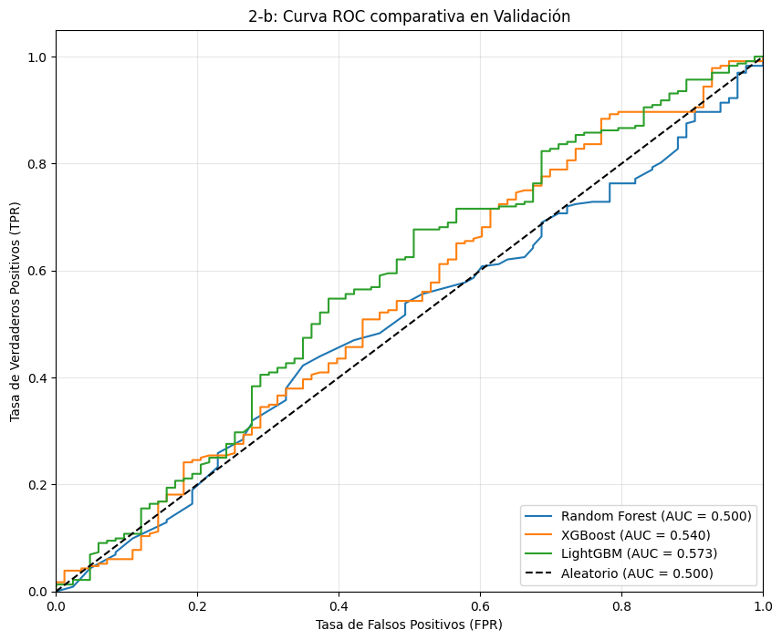

```python
# 2-b (Paso 4): Entrenar modelos y evaluar en validación
from sklearn.metrics import roc_curve, auc
import matplotlib.pyplot as plt
import warnings

# Silenciar warnings
warnings.filterwarnings("ignore")

print("Iniciando entrenamiento de modelos...\n")

# 1. Instanciar los modelos con una semilla fija (random_state) para reproducibilidad
rf_model = RandomForestClassifier(random_state=42)
xgb_model = xgb.XGBClassifier(random_state=42, eval_metric='logloss')
lgb_model = lgb.LGBMClassifier(random_state=42, verbose=-1)

# 2. Entrenar los modelos con el conjunto Train
rf_model.fit(X_train, y_train)
xgb_model.fit(X_train, y_train)
lgb_model.fit(X_train, y_train)

# 3. Predicciones sobre el conjunto de Validación (Clases y Probabilidades)
y_pred_rf = rf_model.predict(X_val)
y_pred_xgb = xgb_model.predict(X_val)
y_pred_lgb = lgb_model.predict(X_val)

y_prob_rf = rf_model.predict_proba(X_val)[:, 1]
y_prob_xgb = xgb_model.predict_proba(X_val)[:, 1]
y_prob_lgb = lgb_model.predict_proba(X_val)[:, 1]

# 4. Evaluación: Matrices de Confusión y Reportes de Clasificación
modelos = {
    'Random Forest': y_pred_rf,
    'XGBoost': y_pred_xgb,
    'LightGBM': y_pred_lgb
}

for nombre, y_pred in modelos.items():
    print(f"================ {nombre} ================")
    print("Matriz de Confusión:")
    print(confusion_matrix(y_val, y_pred))
    print("\nReporte de Clasificación:")
    print(classification_report(y_val, y_pred))

# 5. Curva ROC y cálculo del AUC (Área Bajo la Curva)
plt.figure(figsize=(10, 8))

# Calculamos y graficamos para cada modelo
fpr_rf, tpr_rf, _ = roc_curve(y_val, y_prob_rf)
plt.plot(fpr_rf, tpr_rf, label=f'Random Forest (AUC = {auc(fpr_rf, tpr_rf):.3f})')

fpr_xgb, tpr_xgb, _ = roc_curve(y_val, y_prob_xgb)
plt.plot(fpr_xgb, tpr_xgb, label=f'XGBoost (AUC = {auc(fpr_xgb, tpr_xgb):.3f})')

fpr_lgb, tpr_lgb, _ = roc_curve(y_val, y_prob_lgb)
plt.plot(fpr_lgb, tpr_lgb, label=f'LightGBM (AUC = {auc(fpr_lgb, tpr_lgb):.3f})')

# Línea base (modelo aleatorio)
plt.plot([0, 1], [0, 1], 'k--', label='Aleatorio (AUC = 0.500)')
plt.xlim([0.0, 1.0])
plt.ylim([0.0, 1.05])
plt.xlabel('Tasa de Falsos Positivos (FPR)')
plt.ylabel('Tasa de Verdaderos Positivos (TPR)')
plt.title('2-b: Curva ROC comparativa en Validación')
plt.legend(loc="lower right")
plt.grid(alpha=0.3)
plt.show()
```

LightGBM es el mejor

Tiene el AUC más alto.

Tiene la mayor exactitud general o accuracy (72%).

Lo más importante para el negocio: tiene un recall del 93% para la clase 1 (los que compran), lo que significa que el modelo es excelente identificando a los clientes que van a volver. Su punto débil es predecir a los que no vuelven (clase 0), un reto muy común cuando las clases están desbalanceadas (hay muchos más clientes que compran que los que no).

```
--- 2-b (Paso 5): EXPLICABILIDAD DEL MODELO FINAL (LightGBM) ---
```

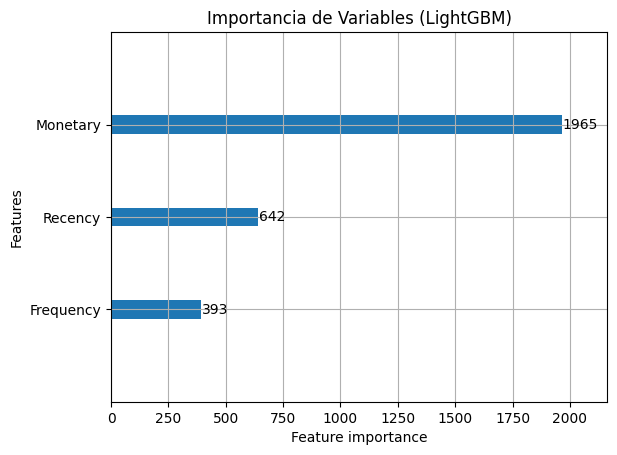

```
Generando SHAP values...
```

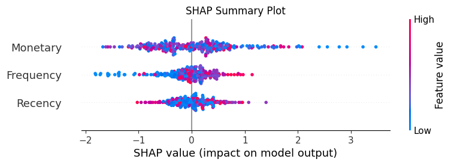

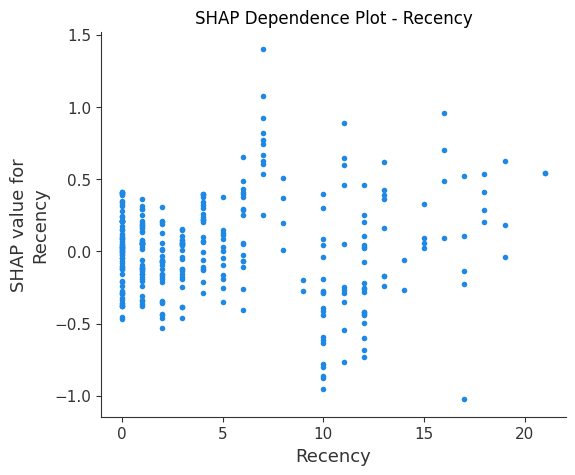

```
Generando Partial Dependence Plots...
```

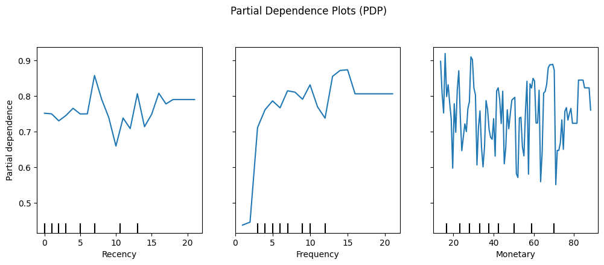

```
Generando Modelo Sustituto (Surrogate Model)...
```

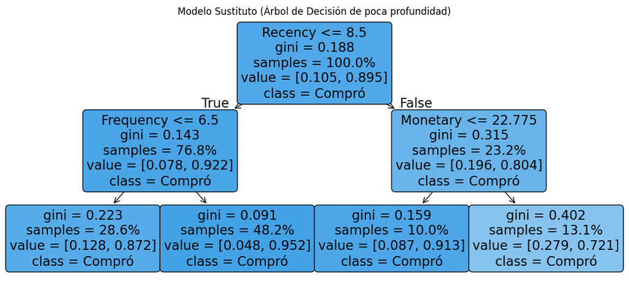

```python
!pip install shap --quiet

import shap
import matplotlib.pyplot as plt
from sklearn.tree import DecisionTreeClassifier, plot_tree
from sklearn.inspection import PartialDependenceDisplay

print("--- 2-b (Paso 5): EXPLICABILIDAD DEL MODELO FINAL (LightGBM) ---\n")

# 1. Feature Importance nativo de LightGBM
lgb.plot_importance(lgb_model, max_num_features=3, title="Importancia de Variables (LightGBM)", importance_type='split')
plt.show()

# 2. SHAP Values
print("\nGenerando SHAP values...")
explainer = shap.TreeExplainer(lgb_model)
shap_values = explainer.shap_values(X_val)
if isinstance(shap_values, list):
    shap_values_to_plot = shap_values[1]
else:
    shap_values_to_plot = shap_values

# SHAP Summary Plot
shap.summary_plot(shap_values_to_plot, X_val, plot_type="dot", show=False)
plt.title("SHAP Summary Plot")
plt.show()

# SHAP Dependence Plot para 'Recency'
shap.dependence_plot("Recency", shap_values_to_plot, X_val, interaction_index=None, show=False)
plt.title("SHAP Dependence Plot - Recency")
plt.show()

# 3. Partial Dependence Plots (PDP) manuales
print("\nGenerando Partial Dependence Plots...")
fig, ax = plt.subplots(figsize=(12, 4))
PartialDependenceDisplay.from_estimator(lgb_model, X_val, ['Recency', 'Frequency', 'Monetary'], ax=ax)
plt.suptitle("Partial Dependence Plots (PDP)", y=1.05)
plt.show()

# 4. Surrogate Model
print("\nGenerando Modelo Sustituto (Surrogate Model)...")
# Entrenamos un árbol simple usando las PREDICCIONES del modelo complejo como variable objetivo
y_pred_train_lgb = lgb_model.predict(X_train)

surrogate_tree = DecisionTreeClassifier(max_depth=2, random_state=42)
surrogate_tree.fit(X_train, y_pred_train_lgb)

plt.figure(figsize=(14, 6))
plot_tree(surrogate_tree, feature_names=X.columns, class_names=['No Compró', 'Compró'], filled=True, rounded=True, proportion=True)
plt.title("Modelo Sustituto (Árbol de Decisión de poca profundidad)")
plt.show()
```

## Apartado 2-b (Paso 6)

# Comentario de resultados (errores, trade-offs y AUC)

# Propuestas de optimización del modelo

Para mejorar el rendimiento predictivo del modelo, se plantean distintas líneas de optimización relacionadas con la ingeniería de variables, el ajuste de hiperparámetros y la automatización del flujo de trabajo. Incorporación de nuevas variables (feature engineering): Actualmente, el modelo utiliza únicamente variables RFM (Recency, Frequency y Monetary). Una posible mejora consistiría en incorporar información adicional, como variables demográficas (edad o género), preferencias de canal de compra (online o tienda física) y métricas relacionadas con la sensibilidad a promociones o descuentos, por ejemplo, la frecuencia de uso de la variable promo_item_yn. Estas variables podrían aportar mayor contexto sobre el comportamiento del cliente y aumentar la capacidad explicativa del modelo. Optimización mediante tuning de hiperparámetros: Podría implementarse un proceso de optimización sistemática de hiperparámetros , con el objetivo de encontrar configuraciones óptimas para parámetros relevantes del modelo, tales como la profundidad máxima de los árboles (max_depth), el número de estimadores o la tasa de aprendizaje (learning_rate). Automatización del pipeline de machine learning: Para acabar, se recomienda desarrollar un pipeline automatizado mediante herramientas como MLflow o los pipelines de scikit-learn. Esto permitiría estructurar de manera reproducible las etapas de preprocesamiento, entrenamiento y evaluación, además de facilitar el reentrenamiento periódico del modelo con datos actualizados. Un esquema de actualización mensual contribuiría a evitar la obsolescencia del modelo y a mantener su capacidad predictiva frente a cambios en el comportamiento de los clientes.

# 3.1. Prácticas para garantizar calidad, trazabilidad y seguridad de los datos

Para asegurar la calidad, trazabilidad y seguridad de los datos usados en el cálculo de CLTV y en la predicción de recompra, aplicaría un marco básico de gobernanza que controle el dato desde su extracción hasta su uso en el modelo.

En primer lugar, revisaría la calidad de los datos de clientes y ventas. Esto incluiría detectar valores nulos, duplicados, fechas incorrectas, importes negativos o incoherencias entre cantidad, precio e importe final. Además, dejaría documentadas las reglas de limpieza aplicadas, como la eliminación de clientes no identificados o el tratamiento de canales desconocidos.

Otro aspecto importante sería aplicar la minimización de datos. Para entrenar un modelo de recompra no es necesario utilizar información directamente identificativa, como nombre, email o número de tarjeta de fidelización. Estos datos deberían eliminarse, anonimizarse o pseudonimizarse, trabajando solo con identificadores técnicos y variables agregadas de comportamiento.

Desde el punto de vista de la seguridad, los datos deberían almacenarse en entornos controlados, con accesos limitados según el rol de cada persona, cifrado, registro de accesos y revisión periódica de permisos. Esto ayuda a reducir el riesgo de accesos no autorizados o fugas de información.

Además, documentaría todo el proceso de modelado: fuentes de datos, variables utilizadas, transformaciones, criterios de exclusión, definición de la variable objetivo, división temporal, modelos entrenados, métricas obtenidas y principales limitaciones. Esta documentación facilita la auditoría, la reproducibilidad y la supervisión del sistema.

También sería recomendable revisar posibles sesgos, comprobando si el modelo funciona de forma parecida en distintos segmentos de clientes, como edad, género, tienda habitual o canal de compra. El objetivo es evitar que las decisiones comerciales afecten de forma injustificada a determinados grupos.

Por último, las predicciones del modelo deberían usarse como apoyo a la decisión, no como decisiones automáticas sin revisión. Además, habría que monitorizar periódicamente la calidad de los datos, el rendimiento del modelo y posibles cambios en el comportamiento de los clientes.

En conjunto, estas medidas están alineadas con los principios del AI Act, especialmente en calidad de datos, trazabilidad, transparencia, supervisión humana, robustez y ciberseguridad. Aunque un modelo de CLTV no tiene por qué considerarse de alto riesgo, aplicar estas prácticas ayuda a mejorar la confianza, reducir riesgos y asegurar un uso responsable de la inteligencia artificial.

## 3.2. Clasificación del sistema según el AI Act

Según el AI Act de la Unión Europea, el sistema de predicción de recompra no se consideraría, en principio, un sistema de alto riesgo si se utiliza solo para calcular el CLTV, segmentar clientes, priorizar campañas de marketing o diseñar acciones de fidelización.

Los sistemas de alto riesgo suelen estar relacionados con ámbitos más sensibles, como biometría, infraestructuras críticas, educación, empleo, acceso a servicios esenciales, seguridad, justicia o procesos democráticos. Un modelo de recompra en retail no encaja directamente en estas categorías, siempre que no se use para tomar decisiones importantes que afecten a derechos fundamentales o al acceso a servicios básicos.

Aun así, el modelo puede tener ciertos riesgos si se usa mal. Por ejemplo, podría excluir a algunos clientes de promociones, generar diferencias de trato o aplicar una personalización poco transparente. Además, si en el futuro se utilizara para decisiones sobre crédito, financiación, precios individualizados sensibles o acceso a servicios esenciales, su nivel de riesgo podría aumentar.

Para reducir estos riesgos, limitaría claramente el uso del modelo a fines comerciales no sensibles y mantendría siempre supervisión humana. Las predicciones deberían servir como apoyo, no como decisiones automáticas incuestionables.

También aplicaría minimización de datos, eliminando o pseudonimizando información identificativa como nombre, email o tarjeta de fidelización. El modelo debería trabajar principalmente con variables agregadas de comportamiento.

Además, revisaría posibles sesgos para comprobar si el modelo afecta de forma desigual a ciertos grupos de clientes, por ejemplo según edad, género, tienda habitual o canal de compra. Si se detectan diferencias injustificadas, habría que revisar las variables, ajustar el modelo o limitar su uso.

Por último, documentaría todo el proceso: fuentes de datos, variables utilizadas, transformaciones, métricas, limitaciones y decisiones de negocio asociadas. También aplicaría medidas de seguridad como acceso restringido, cifrado, registro de accesos y monitorización continua.

Concluyendo, un modelo de predicción de recompra usado para marketing no sería normalmente de alto riesgo según el AI Act, pero debería gestionarse con buenas prácticas de gobernanza, transparencia, seguridad, supervisión humana y control de sesgos.

# 3.3. Inferencia de género a partir de patrones de consumo

Si una empresa quisiera inferir el género de nuevos clientes a partir de sus patrones de consumo, debería hacerlo con mucho cuidado. No estaría solo analizando ventas, sino deduciendo una característica personal del cliente.

Lo primero sería preguntarse si realmente es necesario. Para calcular CLTV, predecir recompra o hacer segmentación comercial, normalmente basta con usar variables de comportamiento, como frecuencia de compra, gasto, canal preferido o respuesta a promociones, sin necesidad de inferir género.

Además, este tipo de modelo puede reforzar sesgos y estereotipos. Por ejemplo, asociar ciertos productos o hábitos de compra a hombres o mujeres puede llevar a recomendaciones poco justas o discriminatorias.

También habría que revisar bien la variable gender usada para entrenar el modelo: cómo se recogió, si fue declarada por el cliente o inferida, si contiene errores y si representa bien a todos los grupos. Si esa variable no es fiable, el modelo tampoco lo será.

Desde el punto de vista legal y ético, la empresa debería garantizar transparencia, minimización de datos, seguridad y una base jurídica adecuada. Los clientes deberían saber si sus datos se usan para hacer este tipo de inferencias.

En conclusión, inferir género a partir del consumo tiene riesgos importantes de privacidad, sesgo y discriminación. Salvo que exista una justificación muy clara, sería mejor segmentar a los clientes por su comportamiento de compra, sin convertir esos patrones en una etiqueta personal como el género.

# 3.4 Campaña personalizada para Baby Boomers

Para diseñar una campaña de marketing personalizada dirigida a clientes de la generación Baby Boomers, habría que tener en cuenta tanto la información generacional como el historial real de compras. La generación puede ser una variable útil de segmentación, pero no debería utilizarse de forma aislada, ya que podría conducir a estereotipos o decisiones poco precisas.

En primer lugar, sería necesario definir correctamente el segmento, por ejemplo a partir del año de nacimiento de los clientes. Habitualmente se considera Baby Boomers a las personas nacidas aproximadamente entre 1946 y 1964. Sin embargo, no todos los clientes de esta generación tienen los mismos hábitos de compra, preferencias de canal o sensibilidad a promociones. Por ello, la campaña debería apoyarse principalmente en variables de comportamiento, como frecuencia de compra, recencia, gasto medio, productos adquiridos, canal utilizado y antigüedad como cliente.

En cuanto al mensaje, sería recomendable utilizar una comunicación clara, directa y orientada al valor. En este segmento podrían ser relevantes mensajes relacionados con confianza, calidad, durabilidad, facilidad de uso, garantía, atención personalizada y servicio postventa. No obstante, estas características deberían validarse con datos reales de comportamiento y no asumirse únicamente por pertenecer a una generación.

También habría que adaptar el canal de comunicación. Si el historial muestra que un cliente compra principalmente en tienda física, puede ser más eficaz una campaña vinculada a su tienda habitual, con atención personalizada o beneficios presenciales. Si el cliente utiliza el canal online, podrían emplearse emails personalizados, recomendaciones digitales o promociones específicas. Lo importante es que el canal elegido responda al comportamiento observado y no a una suposición generacional.

Además, debería evitarse un lenguaje paternalista o basado en estereotipos de edad. No sería adecuado construir mensajes que asuman que los Baby Boomers son poco digitales, necesitan ayuda especial o tienen unas preferencias homogéneas. La comunicación debe ser respetuosa, inclusiva y centrada en beneficios reales para el cliente.

Desde el punto de vista de gobernanza y privacidad, la empresa debería aplicar principios de minimización, transparencia y limitación de finalidad. Los clientes deberían ser informados de que sus datos de compra pueden utilizarse para personalizar ofertas o comunicaciones. Además, la segmentación por generación no debería utilizarse para excluir injustificadamente a clientes de promociones, aplicar condiciones menos favorables o tomar decisiones discriminatorias.

En conclusión, una campaña para Baby Boomers debería combinar la variable generacional con el historial de compras y centrarse en mensajes útiles, claros y respetuosos. La clave no es asumir cómo se comporta un cliente por su edad, sino utilizar los datos de forma responsable para ofrecer comunicaciones relevantes, evitando sesgos, estereotipos y usos discriminatorios.

## 3.5. Uso de datos de consumo para priorizar servicios VIP

Antes de implementar un sistema que utilice datos de consumo, frecuencia de visitas, tienda habitual y gasto total para evaluar la “contribución económica” de los clientes y priorizar el acceso a servicios VIP, la empresa debería analizar cuidadosamente sus implicaciones legales, éticas y de gobernanza.

Para empezar, es necesario definir con claridad la finalidad del sistema. Si se utiliza únicamente para conceder ventajas comerciales adicionales, como promociones, invitaciones o beneficios de fidelización, el riesgo puede ser limitado. Sin embargo, si el sistema condiciona el acceso a servicios relevantes, atención preferente imprescindible o beneficios significativos, el impacto sobre los clientes aumenta y deben aplicarse controles más estrictos.

Desde la perspectiva del AI Act, un sistema de priorización VIP puramente comercial no sería necesariamente de alto riesgo. No obstante, el riesgo dependería del contexto y de las consecuencias reales de la decisión. El AI Act considera especialmente sensibles los sistemas que afectan al acceso a servicios esenciales, crédito, seguros, empleo, educación, justicia u otros ámbitos con impacto significativo en derechos de las personas. Por tanto, aunque este caso no encaje automáticamente como alto riesgo, debería evaluarse si puede producir exclusión, discriminación o perjuicios relevantes.

Un aspecto crítico sería el riesgo de discriminación indirecta. Variables aparentemente neutras, como el gasto total, la tienda habitual o la frecuencia de visitas, pueden estar relacionadas con nivel económico, edad, zona de residencia, disponibilidad horaria, movilidad o acceso a canales digitales. Si el sistema premia únicamente a quienes más gastan o más visitan una tienda concreta, puede dejar sistemáticamente fuera a clientes con menor capacidad económica o con patrones de consumo diferentes.

También habría que aplicar principios de transparencia, minimización y proporcionalidad. Los clientes deberían ser informados de que sus datos de consumo se utilizan para asignar beneficios VIP y deberían conocer, al menos de forma general, los criterios utilizados. Además, la empresa debería limitarse a usar los datos estrictamente necesarios, evitando variables identificativas o inferencias personales innecesarias.

La métrica de “contribución económica” debería diseñarse con cuidado. Basarla solo en gasto total podría ser injusto y favorecer exclusivamente a clientes con mayor poder adquisitivo. Una alternativa más equilibrada sería combinar gasto, recurrencia, antigüedad, participación en el programa de fidelización, satisfacción o interacción con la marca. También podrían ofrecerse vías alternativas de acceso a beneficios VIP, para que el sistema no dependa únicamente de la capacidad de gasto.

Como medidas de mitigación, la empresa debería realizar una evaluación de impacto, documentar el funcionamiento del sistema, revisar posibles sesgos, aplicar supervisión humana, permitir mecanismos de reclamación o revisión, proteger los datos mediante controles de seguridad y monitorizar periódicamente los resultados.

En conclusión, el sistema podría ser aceptable si se usa de forma transparente, proporcional y limitada para conceder beneficios adicionales. Sin embargo, si prioriza o excluye clientes de manera opaca basándose solo en su valor económico, puede generar riesgos de discriminación, pérdida de confianza y trato desigual. Por ello, debería diseñarse con criterios de equidad, privacidad, supervisión humana y gobernanza responsable.